# Explore and Summarize Data - Final Project

Yachen Yan

Saturday, January 31, 2015

```
'data.frame':   4898 obs. of  12 variables:
 $ fixed.acidity       : num  7 6.3 8.1 7.2 7.2 8.1 6.2 7 6.3 8.1 ...
 $ volatile.acidity    : num  0.27 0.3 0.28 0.23 0.23 0.28 0.32 0.27 0.3 0.22 ...
 $ citric.acid         : num  0.36 0.34 0.4 0.32 0.32 0.4 0.16 0.36 0.34 0.43 ...
 $ residual.sugar      : num  20.7 1.6 6.9 8.5 8.5 6.9 7 20.7 1.6 1.5 ...
 $ chlorides           : num  0.045 0.049 0.05 0.058 0.058 0.05 0.045 0.045 0.049 0.044 ...
 $ free.sulfur.dioxide : num  45 14 30 47 47 30 30 45 14 28 ...
 $ total.sulfur.dioxide: num  170 132 97 186 186 97 136 170 132 129 ...
 $ density             : num  1.001 0.994 0.995 0.996 0.996 ...
 $ pH                  : num  3 3.3 3.26 3.19 3.19 3.26 3.18 3 3.3 3.22 ...
 $ sulphates           : num  0.45 0.49 0.44 0.4 0.4 0.44 0.47 0.45 0.49 0.45 ...
 $ alcohol             : num  8.8 9.5 10.1 9.9 9.9 10.1 9.6 8.8 9.5 11 ...
 $ quality             : Factor w/ 7 levels "3","4","5","6",..: 4 4 4 4 4 4 4 4 4 4 ...
[1] 4898   12
[1] "3" "4" "5" "6" "7" "8" "9"

   3    4    5    6    7    8    9
  20  163 1457 2198  880  175    5
```

We can see that we have 4898 observations and we also have 11 input variables and 1 output variable which we can transform from a score to an ordered factor. It has seven levels and highly unbalanced.

# Univariate Plots Section

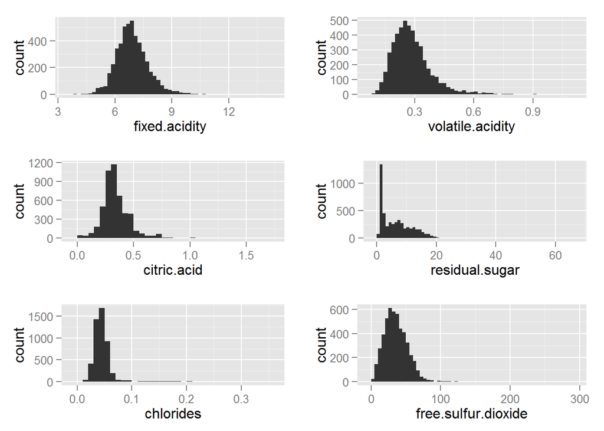

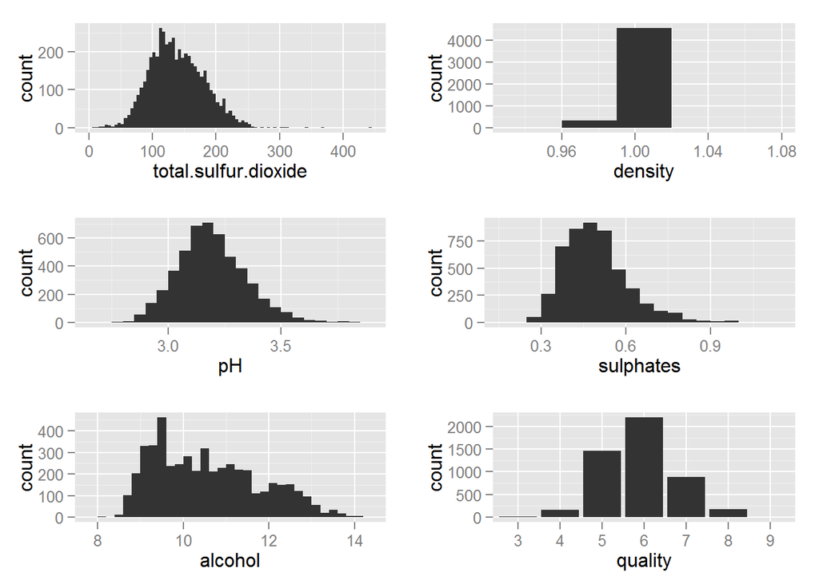

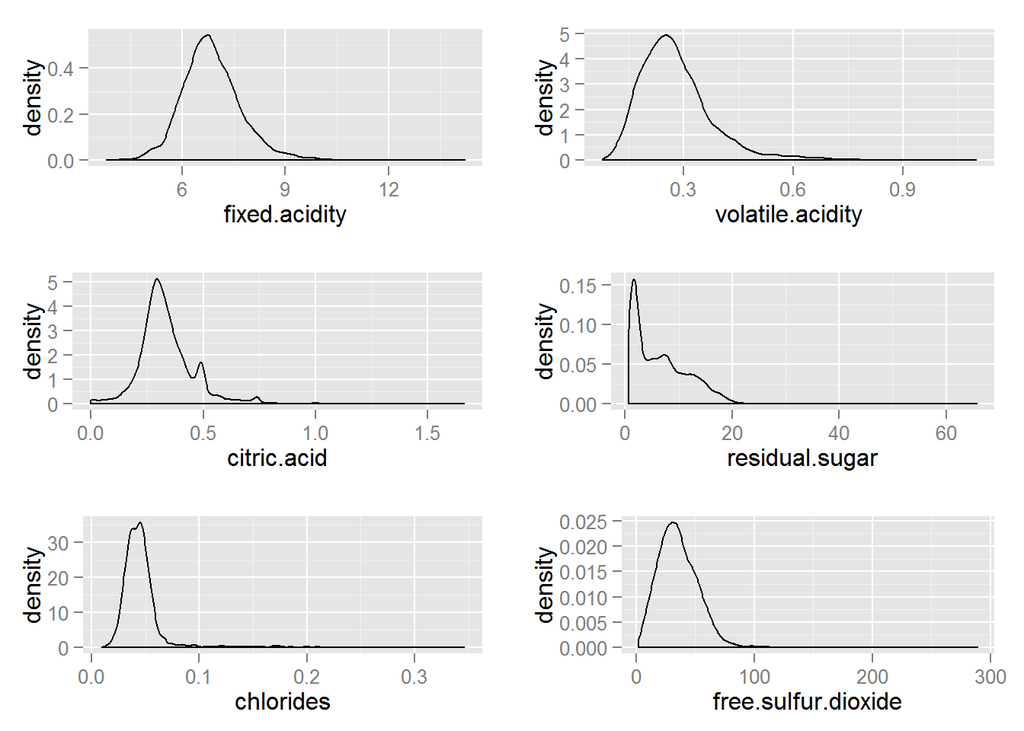

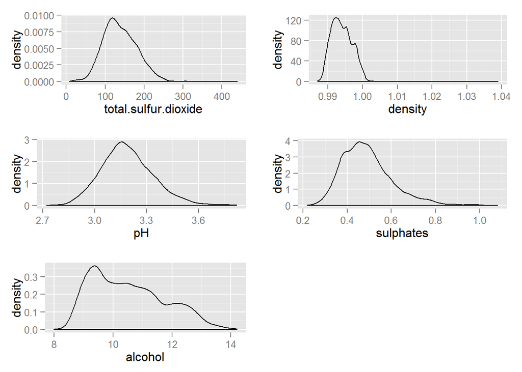

We can see most of variables follow nearly normal distribution with some outliers, except “residual.sugar” and “density” which are highly skewed. For the output variable “quality”, It’s highly unbalanced. That may cause problem if we want to fit a classification model.

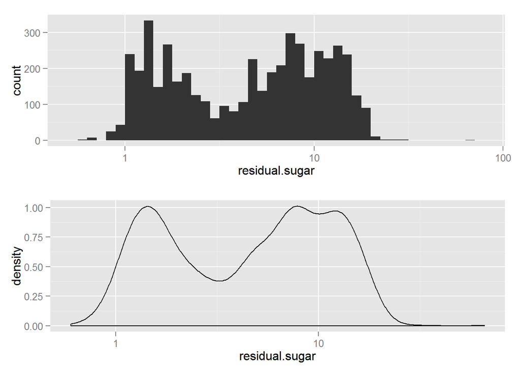

I transformed the “residual.sugar” variable with “log10” transformation. We can see it follows bimodal pattern.

# Univariate Analysis

### What is the structure of your dataset?

There are 4898 observations with 11 input variables and 1 output variable. The input variables are all numeric variable.  
The output variable “quality” has 7 levels and highly unbalanced. “residual.sugar” and “density” are skewed distributed. Other variables basically normally distributed.

### What is/are the main feature(s) of interest in your dataset?

Even though I personally don’t have too much domain knowledge for wine, And even though we have one feature can predict the quality significantly better than others, To answer this question, we may want to fit an nonlinear model and check feature importance. The modeling part is in next question below PCA.

### What other features in the dataset do you think will help support your investigation into your feature(s) of interest?

All the other features are very important. The final score of quality may be calculated in a very complex and unlinear way by those features. We may do feature selection in our modeling part but not now. For now, I just run a PCA first, and I found that it’s very hard too find a few directions that contain most of variance which means basically all the features contain its own information itself.

```
Parallel analysis suggests that the number of factors =  NA  and the number of components =  3

Loadings:
                     PC1    PC2    PC3
fixed.acidity         0.282 -0.737  0.134
volatile.acidity                   -0.653
citric.acid           0.259 -0.433  0.558
residual.sugar        0.767        -0.237
chlorides             0.381        -0.113
free.sulfur.dioxide   0.539  0.364  0.309
total.sulfur.dioxide  0.730  0.306  0.137
density               0.918        -0.143
pH                   -0.231  0.730  0.140
sulphates                    0.280  0.479
alcohol              -0.785         0.117

                 PC1   PC2   PC3
SS loadings    3.222 1.575 1.222
Proportion Var 0.293 0.143 0.111
Cumulative Var 0.293 0.436 0.547
```

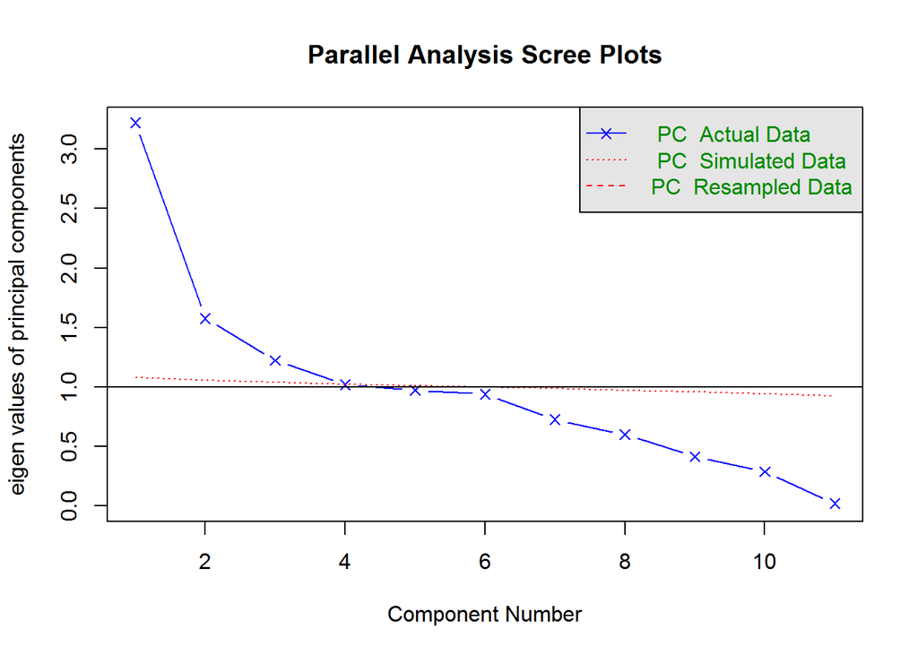

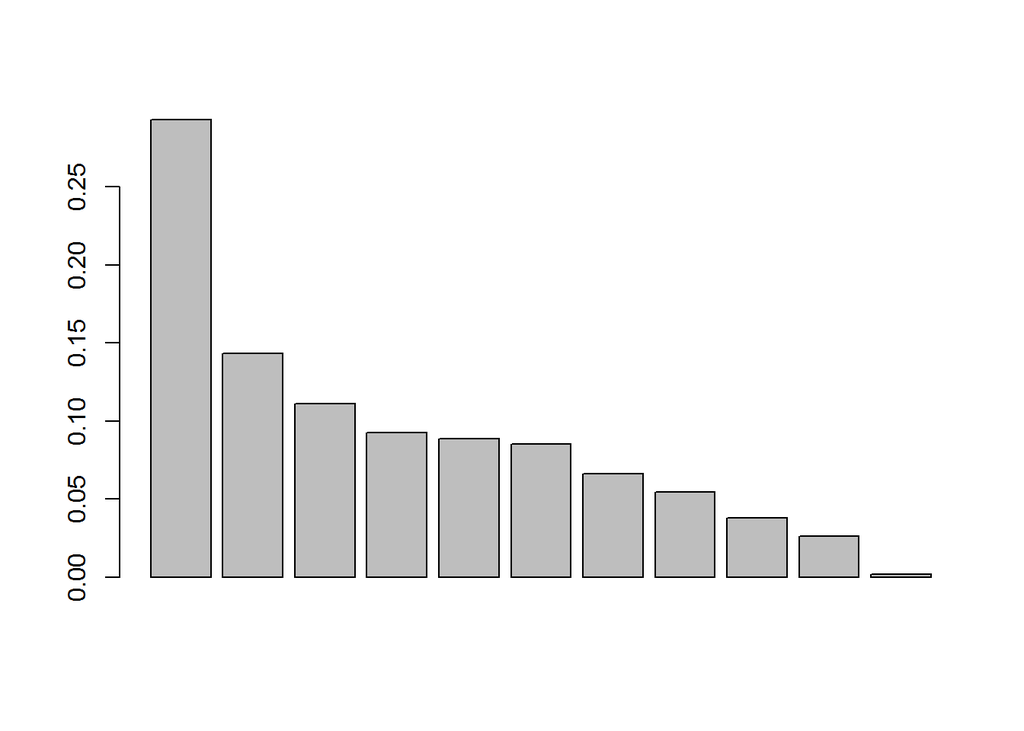

Then, I tries to predict the quality by randomforest. Through the Variable Importance Plot, we can see that the feature “alcohol” can provide us most explanatory power. For computing speed consideration, I didn’t use a large numer for trees to grow. This part is only for the plot but not for very high accuracy.

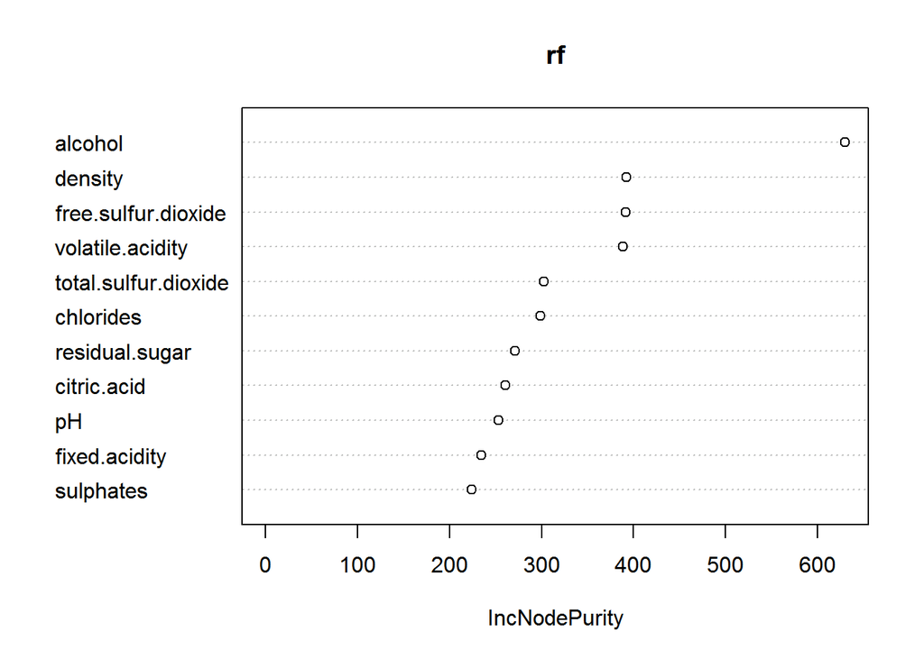

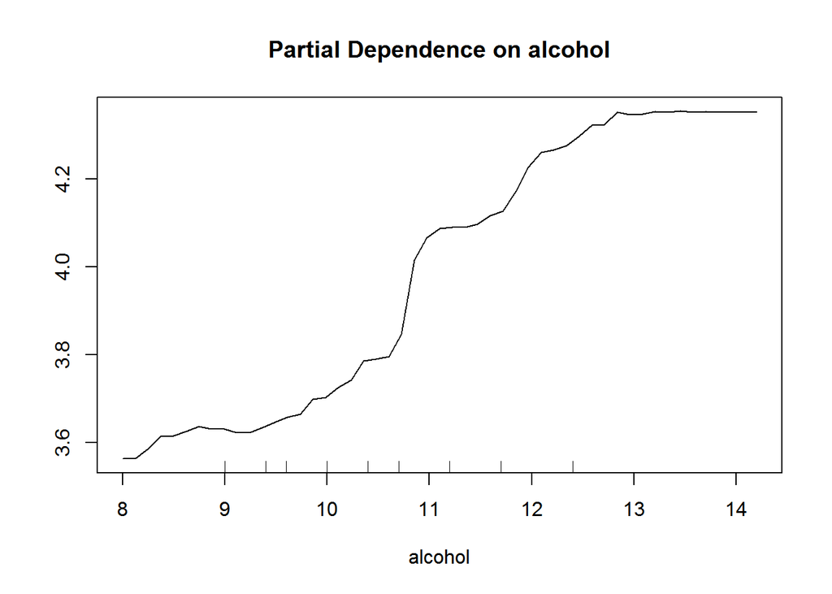

And from the partial dependence plot, we also can see that “alcohol” and “quality” seems having positive correlation. The “quality” tends to be higher when the “alcohol” is high.

### Did you create any new variables from existing variables in the dataset?

I created a categorical variable which is alcohol.category in Multivariate Plots Section. and I also compute the scores of first 3 principal components in PCA in next section.

### Of the features you investigated, were there any unusual distributions? Did you perform any operations on the data to tidy, adjust, or change the form of the data? If so, why did you do this?

The data is pretty tidy and clean. There are no missing values. I log-transformed “residual.sugar” which is right-skewed. And it shows bimodal pattern after transformation.

# Bivariate Plots Section

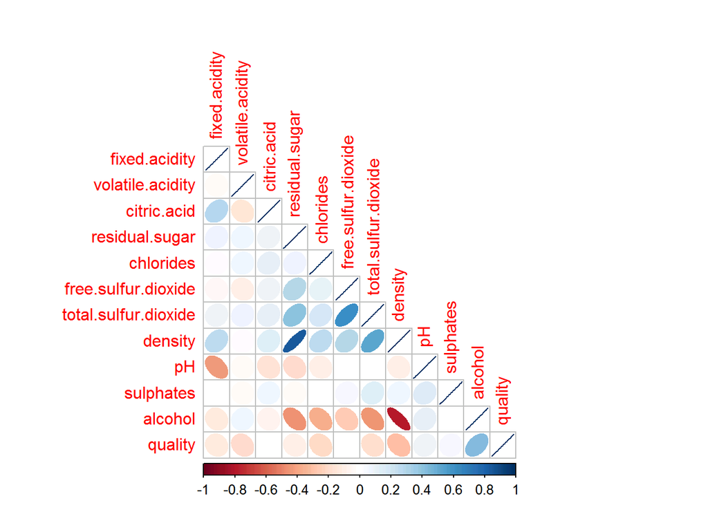

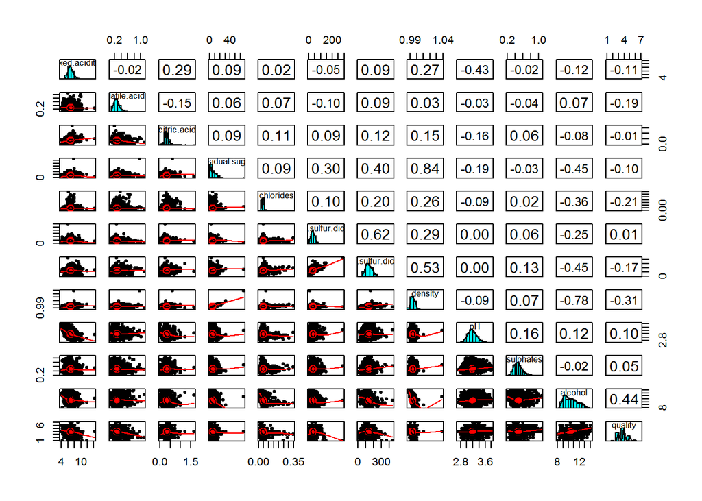

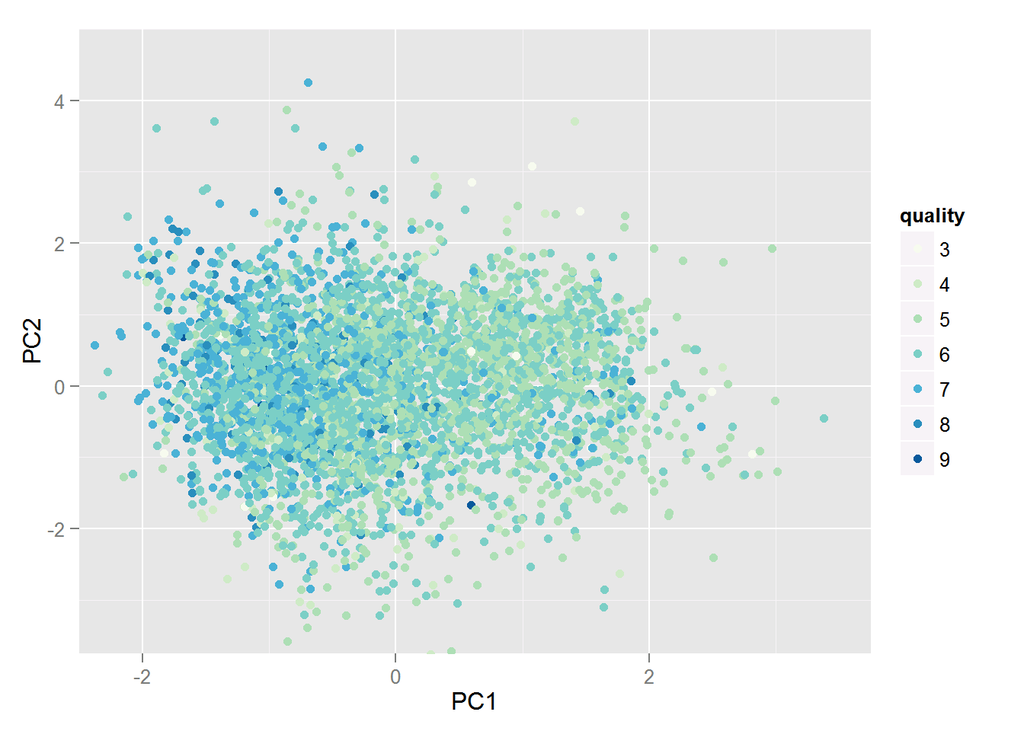

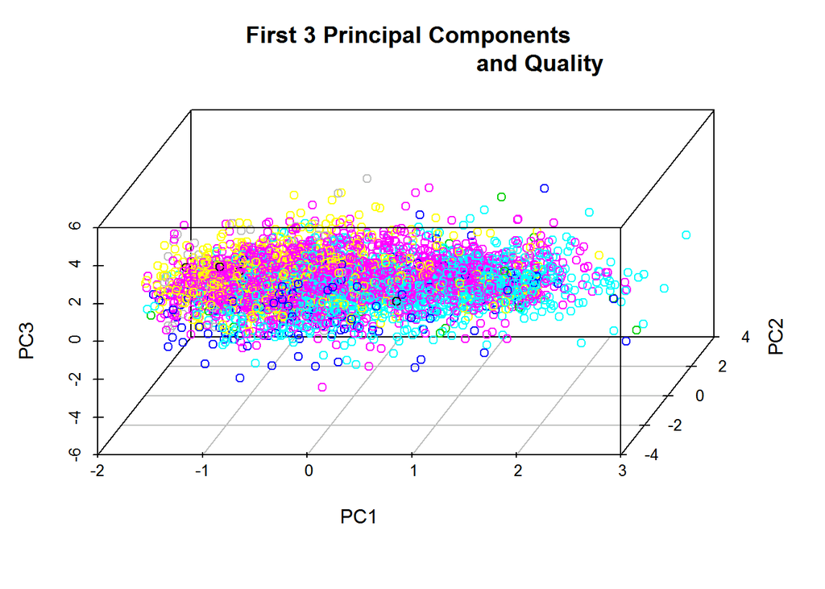

From the correlation matrix, we can see that the “density” variable has some positive correlations with “residual.sugar”, “chlorides”, “free.sulfur.dioxide” and “total.sulfur.dioxide”. And we can also see that “alcohol” has some negative correlations with variables mentioned above. and we can also see that the “alcohol” and “quality” has positive correlation, though not very strong.  
From the scatterplot matrix, we can see that except the correlation we mentioned ablove, other scatterplot between variables show no linear relationship patterns.

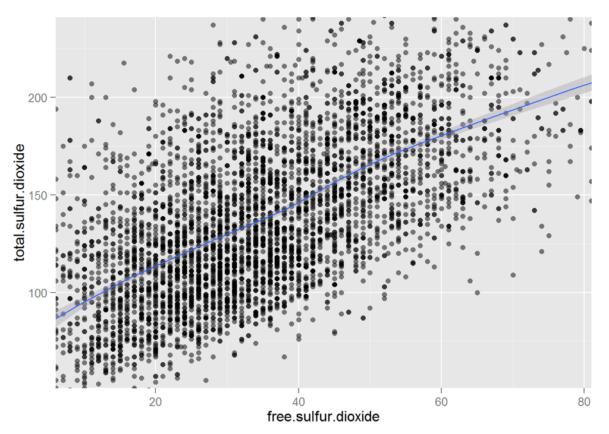

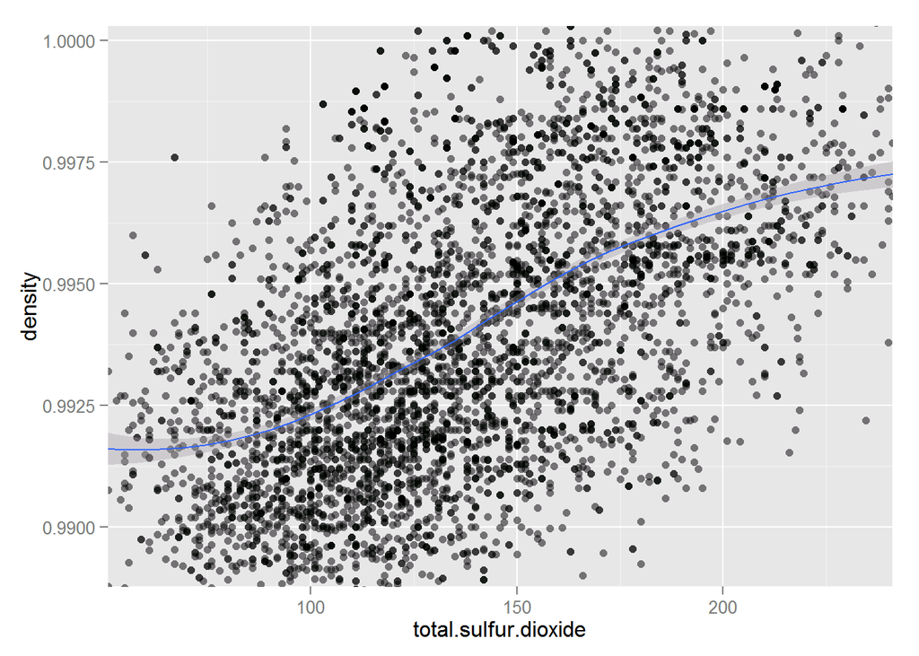

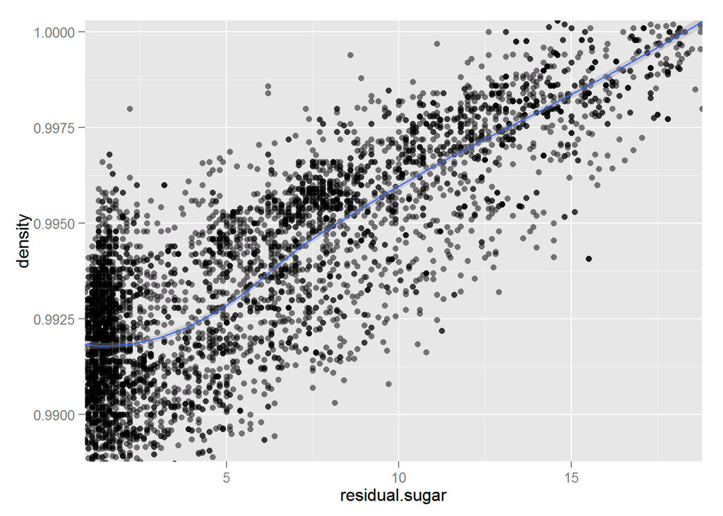

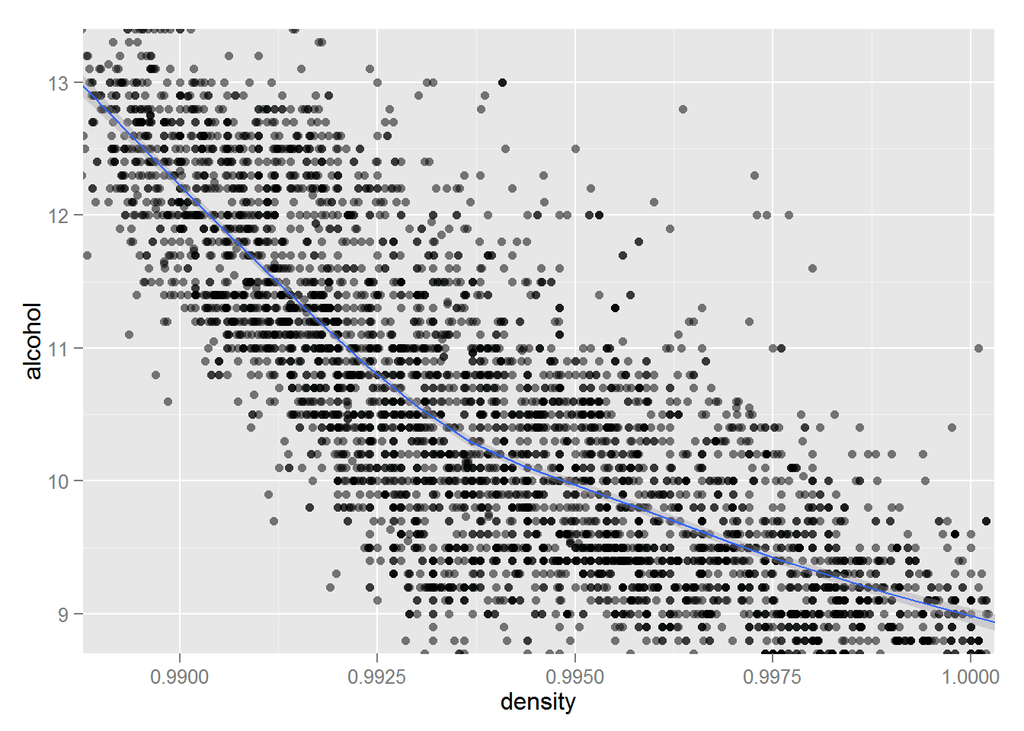

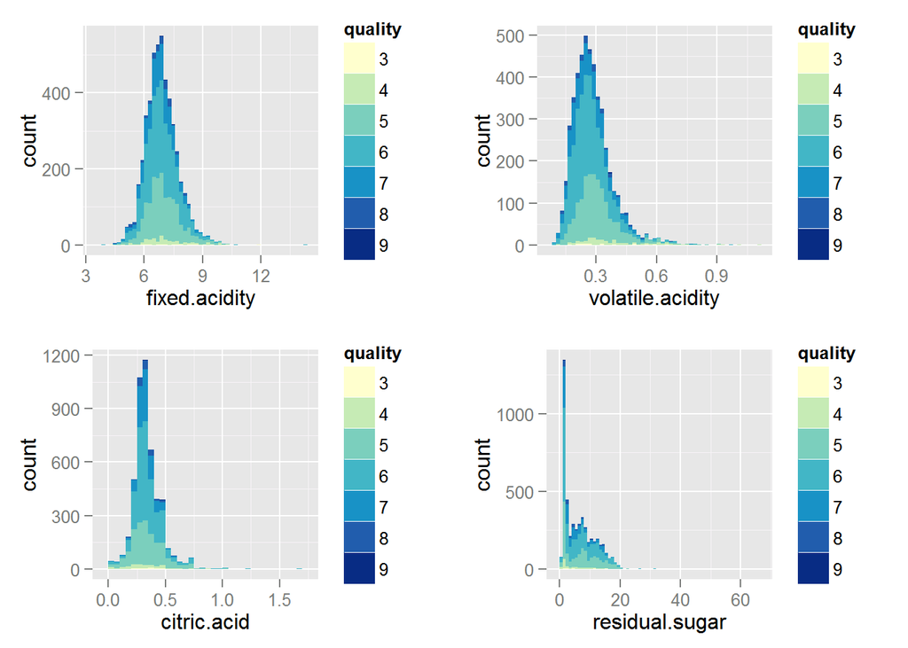

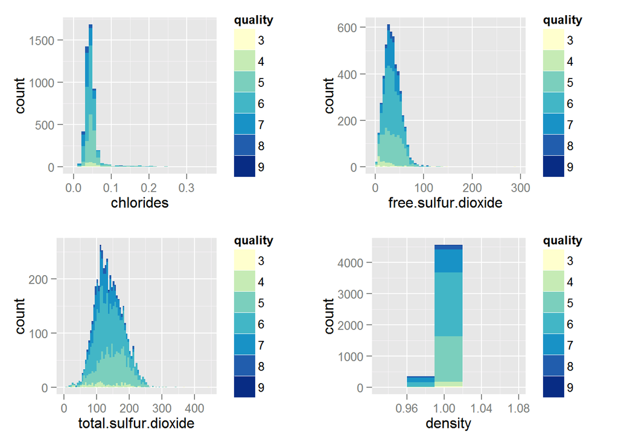

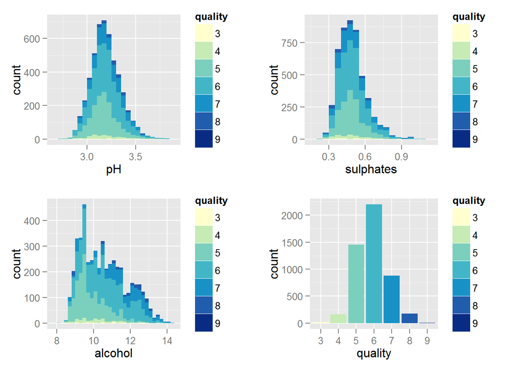

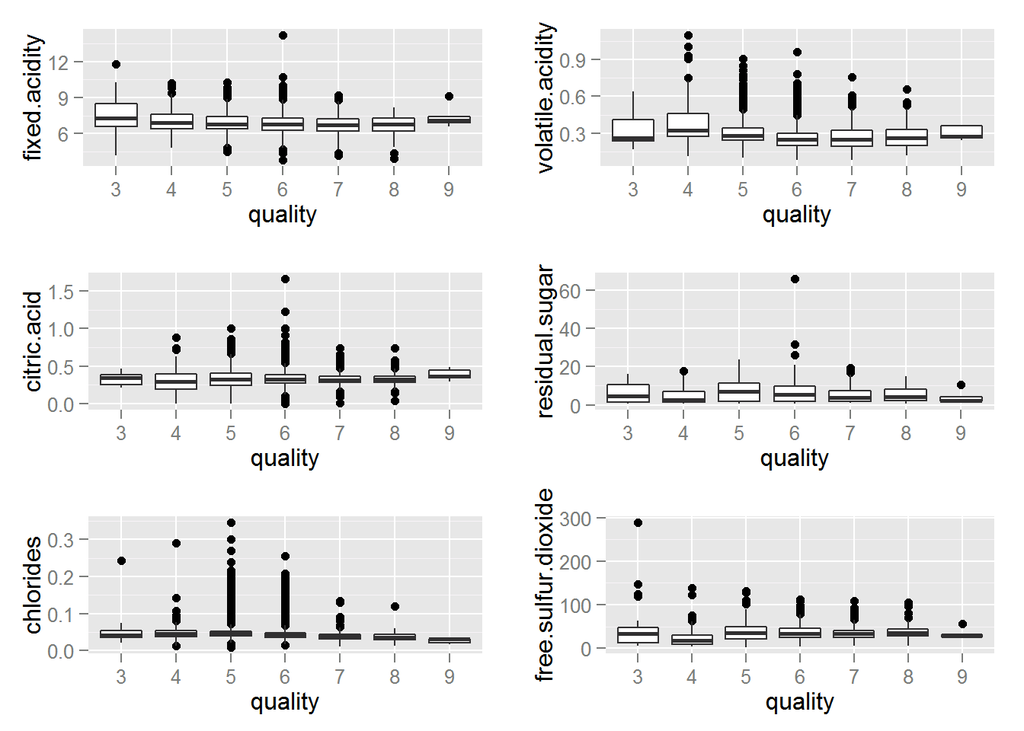

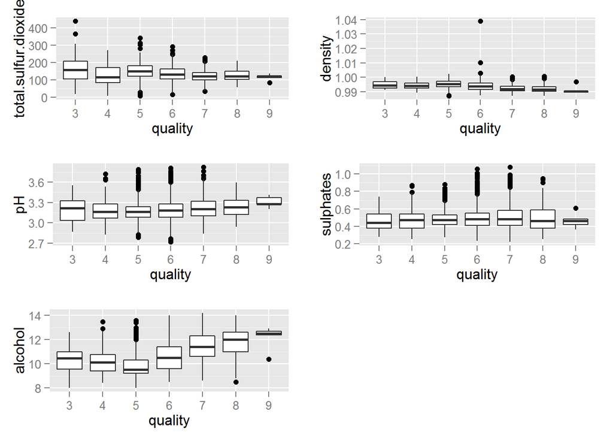

# Bivariate Analysis

### Talk about some of the relationships you observed in this part of the investigation. How did the feature(s) of interest vary with other features in the dataset?

I used correlation matrix plot to observe the correlation between variables. And we could observe positive relationship between “free.sulfur.dioxide” and “total.sulfur.dioxide”, “total.sulfur.dioxide” and “density”, “residual.sugar” and “density”. We could also observe negative relationship between “density” and “alcohol”.

### Did you observe any interesting relationships between the other features (not the main feature(s) of interest)?

If we think that the principal component scores are features after pre-processing. We can see that it explain the relationship better than any features along. And if we carefully check the loading matrix of PCA, we can have better understanding of our data.

### What was the strongest relationship you found?

The variable “density” and “residual.sugar” have very strong positive correlation which is 0.84.

# Multivariate Plots Section

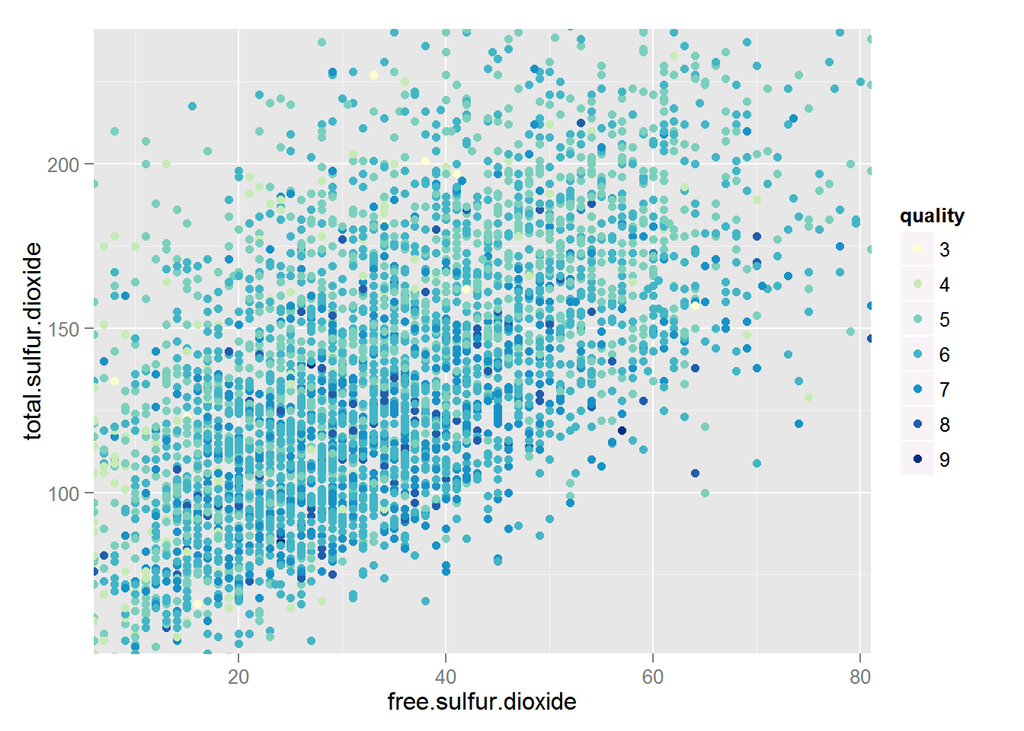

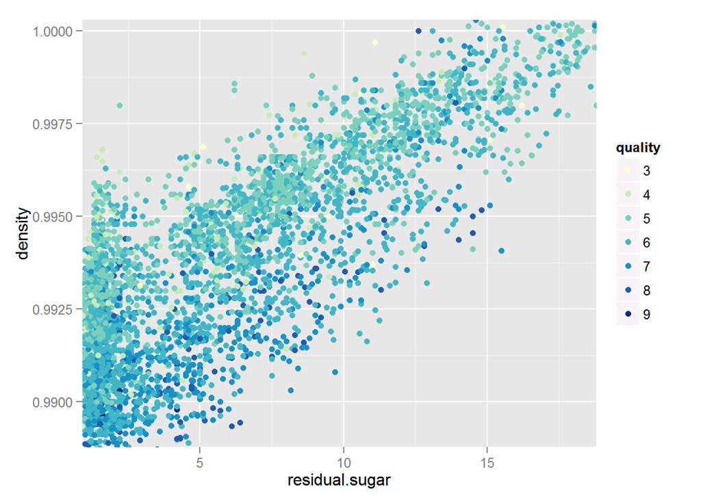

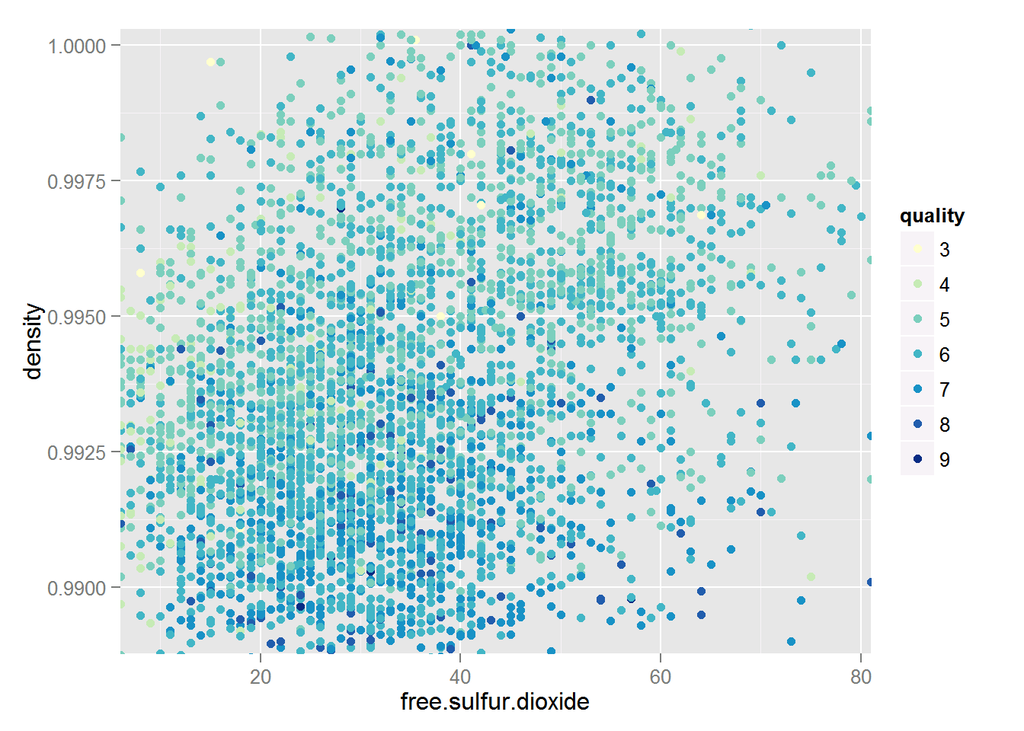

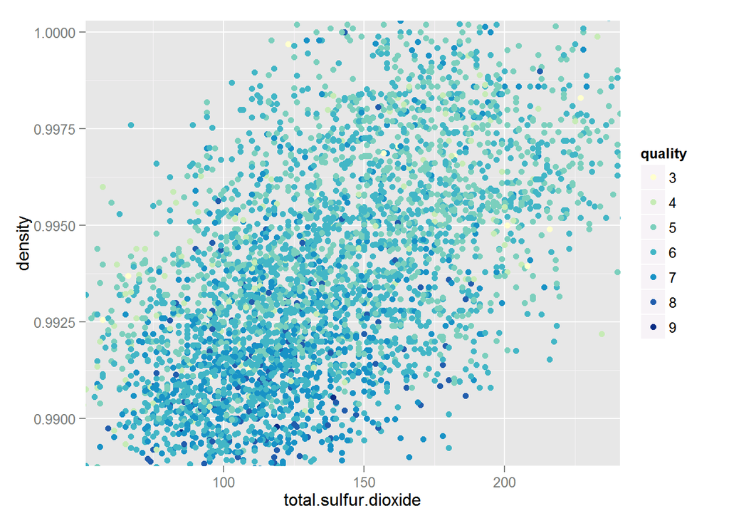

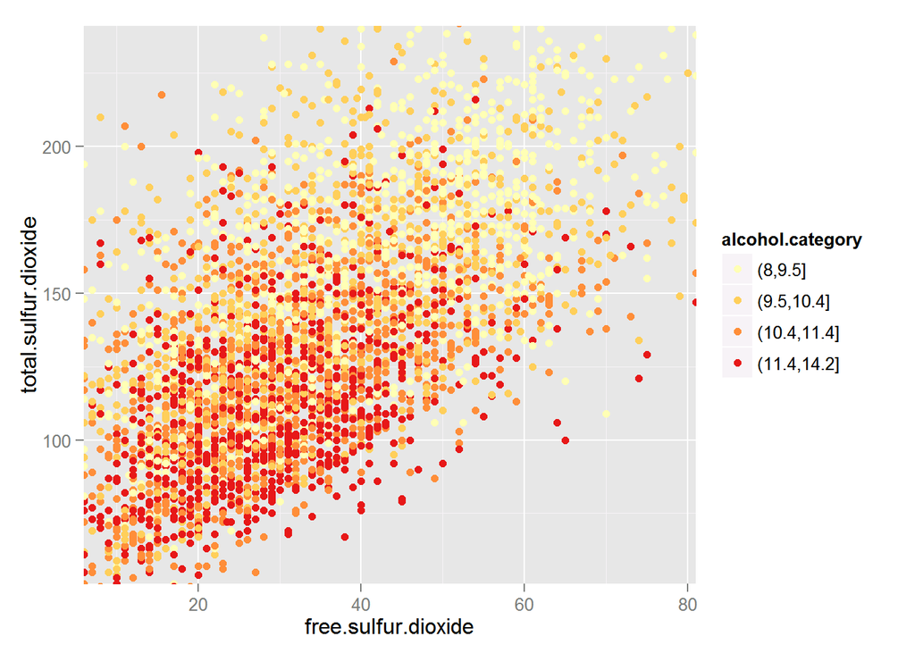

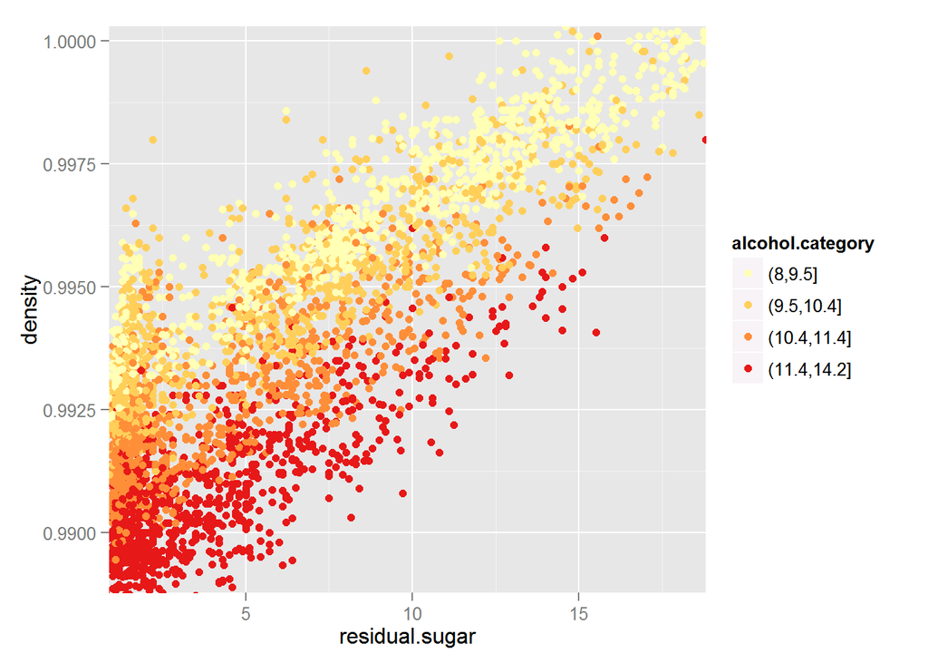

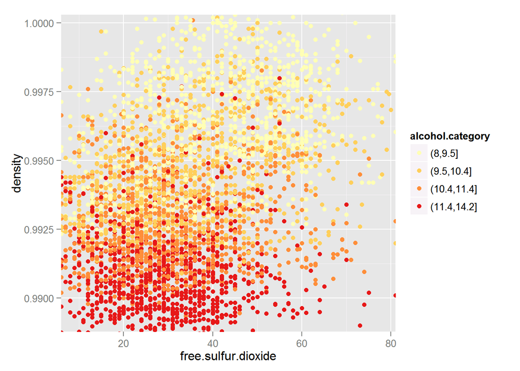

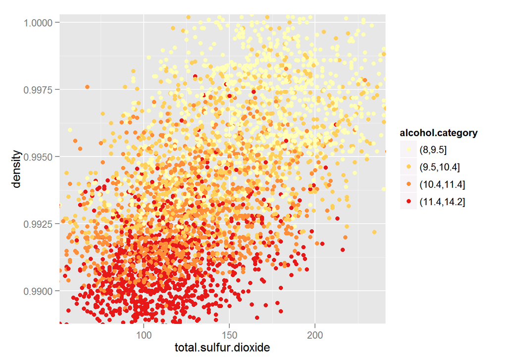

I tried to use strongly correlated variables in a scatterplot coloured by quality to get some sense for classification. But I can’t see very strong clusters on the first 4 plot.  
Then I used “alcohol” to create a categorical variable “alcohol.category”. And I use scatterplot to observe strongly correlated variables and points were coloured by “alcohol.category”. We can see pretty clear but not 100% perfect hyperplanes to separate points.

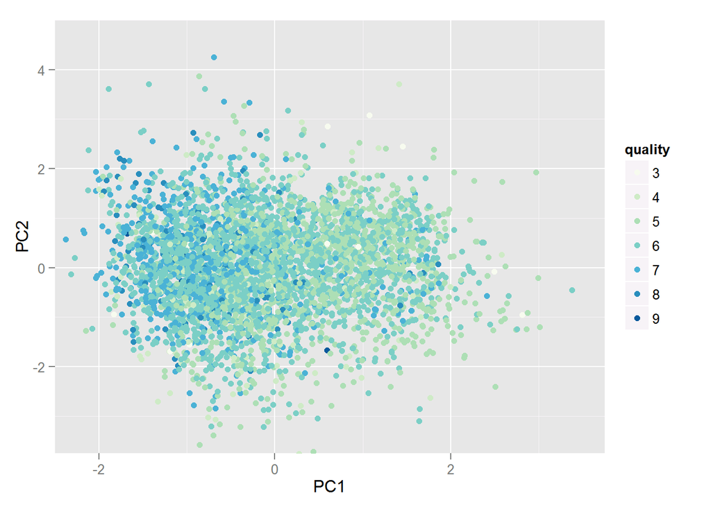

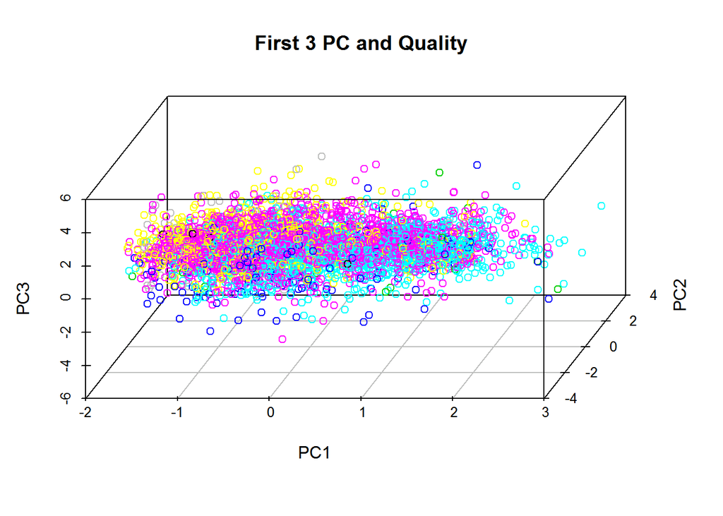

I also used principal component analysis and extract the first 3 scores for visualization. The first graph’s xy-asis is the first 2 component scores and the points is coloured by quality. The second graph’s xyz-asis is the first 3 component scores and the points is coloured by quality. Maybe it’s not very clear to all the people. But I think somehow we can see these data points knd of clustered in the plot. For the 3D plot, if we can rotate this plot, we may find some hyperplanes that can roughly classifficate those data points.